# RNAseq123

Goal: to recap RNA-seq analysis.

code: https://bioconductor.org/packages/release/workflows/vignettes/RNAseq123/inst/doc/limmaWorkflow.R article: https://f1000research.com/articles/5-1408/v3

about the data:

data comes from: https://www.ncbi.nlm.nih.gov/geo/query/acc.cgi?acc=GSE63310

Workflow is from Sheridan et al. (2015). this?: https://pubmed.ncbi.nlm.nih.gov/26080807/ or this?: https://pubmed.ncbi.nlm.nih.gov/25879659/

3 cell populations in triplicate: - **Mammary stem cells (MaSC/basal)** — the “mother” cells that can create all other mammary cell types.  
- **Luminal progenitor cells (LP)** — cells partway along the developmental path; they can still divide and specialize.  
- **Mature luminal cells (ML)** — fully specialized cells that line the ducts and help produce milk.

data: - 100 base-pair single-end reads, aquired by Illumina HiSeq 2000. - count data: https://www.ncbi.nlm.nih.gov/geo/query/acc.cgi?acc=GSE63310 - mouse reference genome (mm10)

# Let’s start the excercise!

```r
# if (!require("BiocManager", quietly = TRUE))
#     install.packages("BiocManager")
#
# BiocManager::install("limma")
# BiocManager::install("Glimma") # installs edger, tidyr, dplyr etc
# BiocManager::install("gridextra")
# BiocManager::install("Mus.musculus")
# install.packages("patchwork")
# install.packages("gplots")
```

maybe redo the whole tutorial

```r
library(limma)
library(Glimma)
library(edgeR)
library(tidyr) # for reshaping data
library(dplyr) # other data manipulation
library(Mus.musculus)
library(ggplot2)
library(grid)
library(gridExtra)
library(patchwork)
library(RColorBrewer)
```

# Data packaging

## Reading in count data

Download and extract count data. Important: there are two files that are not used: - “GSM1545537_mo906111-1_m09611-2.txt” - “GSM1545543_JMS9-CDBG.txt”

todo: check if files are already there

```r
# download
url <- "https://www.ncbi.nlm.nih.gov/geo/download/?acc=GSE63310&format=file"
utils::download.file(url, destfile="data/GSE63310_RAW.tar", mode="wb")
utils::untar("data/GSE63310_RAW.tar", exdir = "data/")

# # extract
# # files <- c("GSM1545535_10_6_5_11.txt", "GSM1545536_9_6_5_11.txt", "GSM1545538_purep53.txt",
# #   "GSM1545539_JMS8-2.txt", "GSM1545540_JMS8-3.txt", "GSM1545541_JMS8-4.txt",
# #   "GSM1545542_JMS8-5.txt", "GSM1545544_JMS9-P7c.txt", "GSM1545545_JMS9-P8c.txt",
# #   "GSM1545537_mo906111-1_m09611-2.txt", "GSM1545543_JMS9-CDBG.txt")
#
files <- c("GSM1545535_10_6_5_11.txt", "GSM1545536_9_6_5_11.txt", "GSM1545538_purep53.txt",
  "GSM1545539_JMS8-2.txt", "GSM1545540_JMS8-3.txt", "GSM1545541_JMS8-4.txt",
  "GSM1545542_JMS8-5.txt", "GSM1545544_JMS9-P7c.txt", "GSM1545545_JMS9-P8c.txt")

for(i in paste("data/", files, ".gz", sep=""))
  R.utils::gunzip(i, overwrite=TRUE)
```

Look at first file in array. I put in a duplicate of the files variable, in case the files were already downloaded and extracted.

```r
files <- c("GSM1545535_10_6_5_11.txt", "GSM1545536_9_6_5_11.txt", "GSM1545538_purep53.txt",
  "GSM1545539_JMS8-2.txt", "GSM1545540_JMS8-3.txt", "GSM1545541_JMS8-4.txt",
  "GSM1545542_JMS8-5.txt", "GSM1545544_JMS9-P7c.txt", "GSM1545545_JMS9-P8c.txt")

read.delim(paste("data/",files[1],sep=""), nrow=5)
```

| EntrezID | GeneLength | Count |
| --- | --- | --- |
| 497097 | 3634 | 1 |
| 100503874 | 3259 | 0 |
| 100038431 | 1634 | 0 |
| 19888 | 9747 | 0 |
| 20671 | 3130 | 1 |

We can lead all the count files in 1 go using edgeR!

I made a mistake and didn’t tell readDGE to select specific columns. This resulted in equal lib siszes. if readDGE takes in a file, it just takes the first two columns. So it only needs files and libsizes of the files.

If you look at the help page of readDGE, by default it uses file names as the label of a sample. Following the help file, it needs 2 data columns: gene names, and counts. So the two columns needed are EntrezID and Count. if it takes geneLength

3634 wikipedia https://en.wikipedia.org/wiki/Library_(biology) library = library is a collection of DNA fragments that is stored and propagated in a population of micro-organisms through the process of molecular cloning

question: is library size the amount of sequences, or the total amount of nucleotides? answer: the amount of molecules (as in: read sequences) https://en.wikipedia.org/wiki/RNA-Seq “Sequencing depth is sometimes referred to as library size, the number of intermediary cDNA molecules in the experiment.” Note: Sequencing depth == library size (2 words for the same thing)

```r
x <- readDGE(files=files, path="data/", columns=c(1,3))
x
```

```
An object of class "DGEList"
$samples
                                        files group lib.size norm.factors
GSM1545535_10_6_5_11 GSM1545535_10_6_5_11.txt     1 32863052            1
GSM1545536_9_6_5_11   GSM1545536_9_6_5_11.txt     1 35335491            1
GSM1545538_purep53     GSM1545538_purep53.txt     1 57160817            1
GSM1545539_JMS8-2       GSM1545539_JMS8-2.txt     1 51368625            1
GSM1545540_JMS8-3       GSM1545540_JMS8-3.txt     1 75795034            1
GSM1545541_JMS8-4       GSM1545541_JMS8-4.txt     1 60517657            1
GSM1545542_JMS8-5       GSM1545542_JMS8-5.txt     1 55086324            1
GSM1545544_JMS9-P7c   GSM1545544_JMS9-P7c.txt     1 21311068            1
GSM1545545_JMS9-P8c   GSM1545545_JMS9-P8c.txt     1 19958838            1

$counts
           Samples
Tags        GSM1545535_10_6_5_11 GSM1545536_9_6_5_11 GSM1545538_purep53 GSM1545539_JMS8-2 GSM1545540_JMS8-3 GSM1545541_JMS8-4
  497097                       1                   2                342               526                 3                 3
  100503874                    0                   0                  5                 6                 0                 0
  100038431                    0                   0                  0                 0                 0                 0
  19888                        0                   1                  0                 0                17                 2
  20671                        1                   1                 76                40                33                14
           Samples
Tags        GSM1545542_JMS8-5 GSM1545544_JMS9-P7c GSM1545545_JMS9-P8c
  497097                  535                   2                   0
  100503874                 5                   0                   0
  100038431                 1                   0                   0
  19888                     0                   1                   0
  20671                    98                  18                   8
27174 more rows ...
```

## Organsing sample information

For simplicity, we remove the GEO sample IDs (GSM*) from the column names of our DGEList-object x. The example states that we need to state the length of the string, but this is not needed.

```r
samplenames <- substring(colnames(x), 12)
samplenames
```

```
[1] "10_6_5_11" "9_6_5_11"  "purep53"   "JMS8-2"    "JMS8-3"    "JMS8-4"    "JMS8-5"    "JMS9-P7c"  "JMS9-P8c"
```

```r
x$samples
```

|  | files | group | lib.size | norm.factors |
| --- | --- | --- | --- | --- |
| GSM1545535_10_6_5_11 | GSM1545535_10_6_5_11.txt | 1 | 32863052 | 1 |
| GSM1545536_9_6_5_11 | GSM1545536_9_6_5_11.txt | 1 | 35335491 | 1 |
| GSM1545538_purep53 | GSM1545538_purep53.txt | 1 | 57160817 | 1 |
| GSM1545539_JMS8-2 | GSM1545539_JMS8-2.txt | 1 | 51368625 | 1 |
| GSM1545540_JMS8-3 | GSM1545540_JMS8-3.txt | 1 | 75795034 | 1 |
| GSM1545541_JMS8-4 | GSM1545541_JMS8-4.txt | 1 | 60517657 | 1 |
| GSM1545542_JMS8-5 | GSM1545542_JMS8-5.txt | 1 | 55086324 | 1 |
| GSM1545544_JMS9-P7c | GSM1545544_JMS9-P7c.txt | 1 | 21311068 | 1 |
| GSM1545545_JMS9-P8c | GSM1545545_JMS9-P8c.txt | 1 | 19958838 | 1 |

we give them the proper names. We also add lane information.

```r
colnames(x) <- samplenames
group <- as.factor(c("LP", "ML", "Basal", "Basal", "ML", "LP", "Basal", "ML", "LP"))
x$samples$group <- group
lane <- as.factor(rep(c("L004","L006","L008"), c(3,4,2)))
x$samples$lane <- lane
x$samples
```

|  | files | group | lib.size | norm.factors | lane |
| --- | --- | --- | --- | --- | --- |
| 10_6_5_11 | GSM1545535_10_6_5_11.txt | LP | 32863052 | 1 | L004 |
| 9_6_5_11 | GSM1545536_9_6_5_11.txt | ML | 35335491 | 1 | L004 |
| purep53 | GSM1545538_purep53.txt | Basal | 57160817 | 1 | L004 |
| JMS8-2 | GSM1545539_JMS8-2.txt | Basal | 51368625 | 1 | L006 |
| JMS8-3 | GSM1545540_JMS8-3.txt | ML | 75795034 | 1 | L006 |
| JMS8-4 | GSM1545541_JMS8-4.txt | LP | 60517657 | 1 | L006 |
| JMS8-5 | GSM1545542_JMS8-5.txt | Basal | 55086324 | 1 | L006 |
| JMS9-P7c | GSM1545544_JMS9-P7c.txt | ML | 21311068 | 1 | L008 |
| JMS9-P8c | GSM1545545_JMS9-P8c.txt | LP | 19958838 | 1 | L008 |

## Organising gene annotations

We are ging to store gene-level information about the counts into the DGElist-object. the rownames of our DGElist-object contain Entrez gene-id’s. We will use those to collect data from biomaRt about the symbol of the gene and the chromosome on which the gene is on.

```r
library(Mus.musculus)
geneid <- rownames(x)
genes <- select(Mus.musculus, keys=geneid, columns=c("SYMBOL","TXCHROM"), keytype="ENTREZID")
dim(genes)
```

```
[1] 27208     3
```

```r
head(genes)
```

|  | ENTREZID | SYMBOL | TXCHROM |
| --- | --- | --- | --- |
| 1 | 497097 | Xkr4 | chr1 |
| 2 | 100503874 | Gm19938 | NA |
| 3 | 100038431 | Gm10568 | NA |
| 4 | 19888 | Rp1 | chr1 |
| 5 | 20671 | Sox17 | chr1 |
| 6 | 27395 | Mrpl15 | chr1 |

There are duplicate ID’s, let’s take a look.

```r
arrange(genes[duplicated(genes$ENTREZID),],ENTREZID)
```

| ENTREZID | SYMBOL | TXCHROM |
| --- | --- | --- |
| 100040048 | Ccl27b | chr4_JH584293_random |
| 100041102 | Pramel42 | chr5_JH584296_random |
| 100041102 | Pramel42 | chr5_JH584297_random |
| 100041354 | Pramel57 | chr5_GL456354_random |
| 100042493 | Ccl21b | chr4_JH584293_random |
| 100042555 | Gm13305 | chr4_JH584293_random |
| 100042555 | Gm13305 | chr4_JH584294_random |
| 100217457 | Snord58b | chr18 |
| 100316809 | Mir1906-1 | chrX |
| 100861978 | NA | chr4_JH584293_random |

[output cut: 19 more lines]

let’s do a check

```r
genes[genes$ENTREZID=="100042555",]
```

|  | ENTREZID | SYMBOL | TXCHROM |
| --- | --- | --- | --- |
| 16094 | 100042555 | Gm13305 | chr4 |
| 16095 | 100042555 | Gm13305 | chr4_JH584293_random |
| 16096 | 100042555 | Gm13305 | chr4_JH584294_random |

As we can see they have different instances. For simplicity, we are going to take the first occurrence. Not the best method, but it doesn’t matter for learning purposes.

```r
genes <- genes[!duplicated(genes$ENTREZID),]
x$genes <- genes
```

Keep in mind that x$genes is ordered the same as the other data, because we only took the first onthology by using duplicated(). if this is not the case, you can use the matchfunction to order correctly.

what we do: 1) Data pre-processing: - transforming from the raw-scale - Removing genes that are lowly expressed - Normalising gene expression distributions

# Data pre-processing

## transforming from the raw-scale

Ways to deal with library size differences: - counts per million (cpm) - log2-cpm - reads per kilobase of transcript per million (RPKM) - fragments per kilobase of transcripts per million (FPKM)

edgeR can calculate cpm and RPKM, we will use cpm. It just takes the count, divides it by the library size and multiplies the answer with 10^6.

LCPM will be used for exploratory plots.

```r
cpm <- cpm(x)
lcpm <- cpm(x, log=TRUE)
head(cpm)
```

```
           Samples
Tags          10_6_5_11    9_6_5_11     purep53     JMS8-2      JMS8-3      JMS8-4      JMS8-5    JMS9-P7c   JMS9-P8c
  497097     0.03042931  0.05660032  5.98311952 10.2397134  0.03958043  0.04957231  9.71202943  0.09384795  0.0000000
  100503874  0.00000000  0.00000000  0.08747251  0.1168028  0.00000000  0.00000000  0.09076663  0.00000000  0.0000000
  100038431  0.00000000  0.00000000  0.00000000  0.0000000  0.00000000  0.00000000  0.01815333  0.00000000  0.0000000
  19888      0.00000000  0.02830016  0.00000000  0.0000000  0.22428910  0.03304821  0.00000000  0.04692397  0.0000000
  20671      0.03042931  0.02830016  1.32958212  0.7786854  0.43538472  0.23133744  1.77902595  0.84463153  0.4008249
  27395     13.11503265 21.81942229 23.93247808 24.6843282 20.63459725 12.70703524 14.84942070 21.96041982 17.1352661
```

I’m very curious if it takes the library size into account automatically. let’s test it.

```r
backup = x$samples[1,"lib.size"]
```

```r
x$samples[1,"lib.size"] = 32132132
test <- cpm(x)
head(test)
```

```
           Samples
Tags         10_6_5_11    9_6_5_11     purep53     JMS8-2      JMS8-3      JMS8-4      JMS8-5    JMS9-P7c   JMS9-P8c
  497097     0.0311215  0.05660032  5.98311952 10.2397134  0.03958043  0.04957231  9.71202943  0.09384795  0.0000000
  100503874  0.0000000  0.00000000  0.08747251  0.1168028  0.00000000  0.00000000  0.09076663  0.00000000  0.0000000
  100038431  0.0000000  0.00000000  0.00000000  0.0000000  0.00000000  0.00000000  0.01815333  0.00000000  0.0000000
  19888      0.0000000  0.02830016  0.00000000  0.0000000  0.22428910  0.03304821  0.00000000  0.04692397  0.0000000
  20671      0.0311215  0.02830016  1.32958212  0.7786854  0.43538472  0.23133744  1.77902595  0.84463153  0.4008249
  27395     13.4133645 21.81942229 23.93247808 24.6843282 20.63459725 12.70703524 14.84942070 21.96041982 17.1352661
```

```r
head(cpm)
```

```
           Samples
Tags          10_6_5_11    9_6_5_11     purep53     JMS8-2      JMS8-3      JMS8-4      JMS8-5    JMS9-P7c   JMS9-P8c
  497097     0.03042931  0.05660032  5.98311952 10.2397134  0.03958043  0.04957231  9.71202943  0.09384795  0.0000000
  100503874  0.00000000  0.00000000  0.08747251  0.1168028  0.00000000  0.00000000  0.09076663  0.00000000  0.0000000
  100038431  0.00000000  0.00000000  0.00000000  0.0000000  0.00000000  0.00000000  0.01815333  0.00000000  0.0000000
  19888      0.00000000  0.02830016  0.00000000  0.0000000  0.22428910  0.03304821  0.00000000  0.04692397  0.0000000
  20671      0.03042931  0.02830016  1.32958212  0.7786854  0.43538472  0.23133744  1.77902595  0.84463153  0.4008249
  27395     13.11503265 21.81942229 23.93247808 24.6843282 20.63459725 12.70703524 14.84942070 21.96041982 17.1352661
```

```r
x$samples[1,"lib.size"] = backup
```

It takes library size into account! Not much of a suprise, but good to see confirmation.

```r
x$samples
```

|  | files | group | lib.size | norm.factors | lane |
| --- | --- | --- | --- | --- | --- |
| 10_6_5_11 | GSM1545535_10_6_5_11.txt | LP | 32863052 | 1 | L004 |
| 9_6_5_11 | GSM1545536_9_6_5_11.txt | ML | 35335491 | 1 | L004 |
| purep53 | GSM1545538_purep53.txt | Basal | 57160817 | 1 | L004 |
| JMS8-2 | GSM1545539_JMS8-2.txt | Basal | 51368625 | 1 | L006 |
| JMS8-3 | GSM1545540_JMS8-3.txt | ML | 75795034 | 1 | L006 |
| JMS8-4 | GSM1545541_JMS8-4.txt | LP | 60517657 | 1 | L006 |
| JMS8-5 | GSM1545542_JMS8-5.txt | Basal | 55086324 | 1 | L006 |
| JMS9-P7c | GSM1545544_JMS9-P7c.txt | ML | 21311068 | 1 | L008 |
| JMS9-P8c | GSM1545545_JMS9-P8c.txt | LP | 19958838 | 1 | L008 |

The lib size of 10_6_5_11 is: 32.863.052. So 1 cpm for a gene is equal to 32.8 counted reads.

log-cpm are used for exploration of the data. log transform scales down extreme values, while leaving smaller values more the same (relatively speaking). lcpm() uses 2log by default, wich is handy. lcpm() doesn’t take the 2log of 0, which is undefined, which is nice.

In the example the look at the mean and median of the library sizes as cpm,so we divide by 10^6. a count of zero translates to -4.51 in this dataset (see tutorial).

```r
L <- mean(x$samples$lib.size) / 10^6
M <- median(x$samples$lib.size) * 1e-6
c(L, M)
```

```
[1] 45.48855 51.36862
```

```r
summary(lcpm)
```

```
   10_6_5_11          9_6_5_11          purep53             JMS8-2            JMS8-3            JMS8-4            JMS8-5
 Min.   :-4.5074   Min.   :-4.5074   Min.   :-4.50743   Min.   :-4.5074   Min.   :-4.5074   Min.   :-4.5074   Min.   :-4.50743
 1st Qu.:-4.5074   1st Qu.:-4.5074   1st Qu.:-4.50743   1st Qu.:-4.5074   1st Qu.:-4.5074   1st Qu.:-4.5074   1st Qu.:-4.50743
 Median :-0.6847   Median :-0.3589   Median :-0.09513   Median :-0.0901   Median :-0.4281   Median :-0.4064   Median :-0.07152
 Mean   : 0.1714   Mean   : 0.3312   Mean   : 0.43559   Mean   : 0.4089   Mean   : 0.3225   Mean   : 0.2529   Mean   : 0.40428
 3rd Qu.: 4.2913   3rd Qu.: 4.5601   3rd Qu.: 4.60081   3rd Qu.: 4.5475   3rd Qu.: 4.5772   3rd Qu.: 4.3199   3rd Qu.: 4.42513
 Max.   :14.7632   Max.   :13.4952   Max.   :12.95700   Max.   :12.8513   Max.   :12.9578   Max.   :14.8520   Max.   :13.19491
    JMS9-P7c          JMS9-P8c
 Min.   :-4.5074   Min.   :-4.5074
 1st Qu.:-4.5074   1st Qu.:-4.5074
 Median :-0.1704   Median :-0.3300
 Mean   : 0.3708   Mean   : 0.2749
 3rd Qu.: 4.6031   3rd Qu.: 4.4355
 Max.   :12.9413   Max.   :14.0102
```

Keep in mind that negative lcpm are just cpm, smaller than 1.

note: voom (from limma) uses log-cpm, although voom recomputes its own log-CPM values internally with a smaller prior count.

## Removing genes that are lowly expressed

x$counts==0 : get a true for every gene that has no counts regardless of sample. rowSums(x$counts==0) : sums the rows (it sums the TRUE values (so the 1’s)). rowSums(x$counts==0)==9 : gives a true for 9 trues in a row, so a true for every column/sample. In other words there are no counts for this gene in any of the samples. table(rowSums(x$counts==0)==9) : count rows without any value and with a value.

```r
table(rowSums(x$counts==0)==9)
```

```
FALSE  TRUE
22026  5153
```

```r
table(rowSums(x$counts==0)==9)["TRUE"] / (table(rowSums(x$counts==0)==9)["FALSE"] + table(rowSums(x$counts==0)==9)["TRUE"]) * 100
```

```
    TRUE
18.95949
```

19% of the genes have no counts in all samples.

The figure in the example states that there are a low of low expressed genes. I’m going to try plotting that graph from scratch, no hand-holding. The local minimum is at about 0, but i’m too lazy to figure that one out, so…

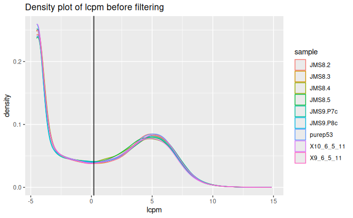

```r
melted <- data.frame(lcpm) %>% gather()
names(melted) = c("sample","lcpm")
plot.bf <- ggplot(data=melted, aes(x=lcpm, color=sample, )) +
  geom_density() +
  labs(title="Density plot of lcpm before filtering") +
  geom_vline(xintercept=0.2)
plot.bf
```

I’ts a nicer plot with less code, this is hilarious.

Automatic filtering by expression level. Group takes in the name of the group column from the samples datasheet. I’m not sure about the third argument. It’s a DGEList object, with an label var, column var, and the third must be other options?? A bit weird way to do it like that, oh well….

```r
keep.expr <- filterByExpr(x, group=group)
x.no_low_expr <- x[keep.expr,,keep.lib.sizes=FALSE]
dim(x.no_low_expr)
```

```
[1] 16624     9
```

By default it keeps genes that have at least 10 read counts. In reality the function calculates cpm and calculates a cut-off that correspondents to 10 read counts. There are 3 replicates per cell group. NOTE: An biological interesting gene should be expressed in at least all replicates.

The cutoff used depends on the sequencing depth and the experimental design. IMPORTANT: A larger library size gives a better resolution at lower expression levels, so then we can take a lower cpm. A smaller libsize gives worse resolution at lower expressed levels, so then we must take a higer cpm.

```r
(16624 - 27208) / 27208 * 100
```

```
[1] -38.90032
```

Note that subsetting the entire DGEList-object removes both the counts and the associated gene information for the filtered genes. The filtered DGEList-object keeps the gene information and the counts for the retained genes correctly associated.

IMPORTANT NOTE FROM TUTORIAL: A biologically interesting gene should be expressed in at least three samples because all the cell type groups have three replicates.

So always use filterByExpr().

```r
x
```

```
An object of class "DGEList"
$samples
                             files group lib.size norm.factors lane
10_6_5_11 GSM1545535_10_6_5_11.txt    LP 32863052            1 L004
9_6_5_11   GSM1545536_9_6_5_11.txt    ML 35335491            1 L004
purep53     GSM1545538_purep53.txt Basal 57160817            1 L004
JMS8-2       GSM1545539_JMS8-2.txt Basal 51368625            1 L006
JMS8-3       GSM1545540_JMS8-3.txt    ML 75795034            1 L006
JMS8-4       GSM1545541_JMS8-4.txt    LP 60517657            1 L006
JMS8-5       GSM1545542_JMS8-5.txt Basal 55086324            1 L006
JMS9-P7c   GSM1545544_JMS9-P7c.txt    ML 21311068            1 L008
JMS9-P8c   GSM1545545_JMS9-P8c.txt    LP 19958838            1 L008

$counts
           Samples
Tags        10_6_5_11 9_6_5_11 purep53 JMS8-2 JMS8-3 JMS8-4 JMS8-5 JMS9-P7c JMS9-P8c
  497097            1        2     342    526      3      3    535        2        0
  100503874         0        0       5      6      0      0      5        0        0
  100038431         0        0       0      0      0      0      1        0        0
  19888             0        1       0      0     17      2      0        1        0
  20671             1        1      76     40     33     14     98       18        8
27174 more rows ...

$genes
   ENTREZID  SYMBOL TXCHROM
1    497097    Xkr4    chr1
2 100503874 Gm19938    <NA>
3 100038431 Gm10568    <NA>
4     19888     Rp1    chr1
5     20671   Sox17    chr1
27174 more rows ...
```

```r
x.no_low_expr
```

```
An object of class "DGEList"
$samples
                             files group lib.size norm.factors lane
10_6_5_11 GSM1545535_10_6_5_11.txt    LP 32857304            1 L004
9_6_5_11   GSM1545536_9_6_5_11.txt    ML 35328624            1 L004
purep53     GSM1545538_purep53.txt Basal 57147943            1 L004
JMS8-2       GSM1545539_JMS8-2.txt Basal 51356800            1 L006
JMS8-3       GSM1545540_JMS8-3.txt    ML 75782871            1 L006
JMS8-4       GSM1545541_JMS8-4.txt    LP 60506774            1 L006
JMS8-5       GSM1545542_JMS8-5.txt Basal 55073018            1 L006
JMS9-P7c   GSM1545544_JMS9-P7c.txt    ML 21305254            1 L008
JMS9-P8c   GSM1545545_JMS9-P8c.txt    LP 19955335            1 L008

$counts
        Samples
Tags     10_6_5_11 9_6_5_11 purep53 JMS8-2 JMS8-3 JMS8-4 JMS8-5 JMS9-P7c JMS9-P8c
  497097         1        2     342    526      3      3    535        2        0
  20671          1        1      76     40     33     14     98       18        8
  27395        431      771    1368   1268   1564    769    818      468      342
  18777        768     1722    2517   1923   3865   1888   1830     1246      693
  21399        810      977    2472   1870   2251   1716   1932      756      619
16619 more rows ...

$genes
  ENTREZID SYMBOL TXCHROM
1   497097   Xkr4    chr1
5    20671  Sox17    chr1
6    27395 Mrpl15    chr1
7    18777 Lypla1    chr1
9    21399  Tcea1    chr1
16619 more rows ...
```

Now we make the graph again, but first calculate lcpm again.

[figure not shown]

```r
# .nl = no low expressed genes
cpm.nl <- cpm(x.no_low_expr)
lcpm.nl <- cpm(x.no_low_expr, log=TRUE)

melted.nl <- data.frame(lcpm.nl) %>% gather()
names(melted.nl) = c("sample","lcpm")

plot.nl <- ggplot(data=melted.nl, aes(x=lcpm, color=sample, )) +
  geom_density() +
  labs(title="Density plot of lcpm before filtering") +
  geom_vline(xintercept=0.2)
plot.nl
```

Let’s put them side by side for the hell of it. I need to find a better package for this…. I used to have a good one, but can’t remember it’s name..

[figure not shown]

```r
grid.arrange(plot.nl, plot.bf, ncol=2)
```

## Normalising gene expression distributions

It can be that an sample has an overal higher expression than another one. This can occur due to external factors, which gives a skewed result for the samples. “It is assumed that all samples should have a similar range and distribution of expression values.” so we arew going to normalize the gene expression **distribution** across samples.

You can see in the previous plots that the distributions are close to being the same (all the lines moslty overlap). So it isn’t really needed, but we do it anyway, for learning sake. The normalisation we will use is trimmed mean of M-values (TMM).

Oeh! This is handy: an explenation of all gene expression units: https://www.reneshbedre.com/blog/expression_units.html#:~:text=TMM%20%28Trimmed%20Mean%20of%20M-values%29%20Permalink.%20TMM%20is,most%20of%20the%20genes%20are%20not%20differentially%20expressed.

- TMM is a between-sample normalization method in contrast to within-sample normalization methods (RPM, RPKM/FPKM, or TPM)
- TMM normalization method assumes that most of the genes are not differentially expressed
- TMM normalize the total RNA output among the samples and does not consider gene length or library size for normalization (NOTE: so great with cpm(?)).
- TMM considers sample RNA population and effective in normalization of samples with diverse RNA repertoires (e.g. samples from different tissues). TMM will be good choice to remove the batch effects while comparing the samples from different tissues or genotypes or in cases where RNA population would be significantly different among the samples.
- TMM is implemented in edgeR and performs better for between-samples comparisons
- edgeR does not consider gene length for normalization as it assumes that the gene length would be constant between the samples
- to calculate: M = log 2 fold change between two samples M = log2(treated sample count / control sample count) A = absolute expression count A = (log2(treated sample count) + log2(control sample count)) / 2 double trimm the lower and upper percentages of the data: trim M by 30% and a by 5%. get weighted mean of M after trimming and calculate normalisation factor. Robinson et al., 2010.: https://pubmed.ncbi.nlm.nih.gov/19910308/

```r
# puts normalisation factors in x$samples$norm.factors
x <- calcNormFactors(x.no_low_expr, method = "TMM")
x$samples$norm.factors
```

```
[1] 0.8943956 1.0250186 1.0459005 1.0458455 1.0162707 0.9217132 0.9961959 1.0861026 0.9839203
```

The effects of normalisation are a bit small, so visualizing will be difficult. So we cheat and andjust the counts in the first sample to 5% of original value, and the second sample 5x larger.

```r
x2 <- x
x2$samples$norm.factors <- 1
x2$counts[,1] <- ceiling(x2$counts[,1]*0.05)
x2$counts[,2] <- x2$counts[,2]*5
```

```r
lcpm_unnormalised <- cpm(x2, log=TRUE)
lcpm_normalised <- cpm(calcNormFactors(x2), log=TRUE)
```

ggplot doesn’t allow this format.

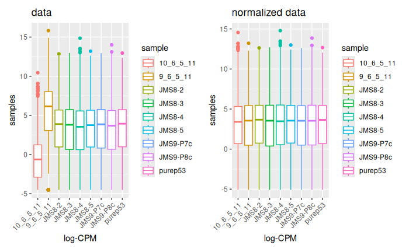

```r
lcpm_unnorm_long <- lcpm_unnormalised %>%
  as.data.frame() %>%
  pivot_longer(
    everything(),
    names_to = "sample",
    values_to = "cpm" )

lcpm_norm_long <- lcpm_normalised %>%
  as.data.frame() %>%
  pivot_longer(
    everything(),
    names_to = "sample",
    values_to = "cpm" )

unnorm_plotn <- ggplot(lcpm_unnorm_long, aes(x = sample, y = cpm)) + geom_boxplot(aes(color=sample)) + theme(axis.text.x = element_text(angle = 45, hjust = 1)) + ggtitle("data") + xlab("log-CPM") + ylab("samples")

norm_plotn <- ggplot(lcpm_norm_long, aes(x = sample, y = cpm)) + geom_boxplot(aes(color=sample)) + theme(axis.text.x = element_text(angle = 45, hjust = 1)) + ggtitle("normalized data") + xlab("log-CPM") + ylab("samples")

unnorm_plotn + norm_plotn
```

# Unsupervised clustering of samples

“In our opinion, one of the most important exploratory plots to examine for gene expression analyses is the multi-dimensional scaling (MDS) plot, or similar.”

what does that mean? I guess that it means that the stemmcels behave diffently from the proginator and kuminal cells. that makes sence.

So there are distingc diffenrce between sample groups, that is good. but ML and LP share charistics in the first dimension.

what does that mean? The proginator cells and the luminal cells are (al lot) less different compared to the difference between the basal slemm cells and the rest. makes sence.

in the sequencing lanes plot, the samples are all over the place.

what does that mean? I guess that’s good. because the lanes should not have an effect on the experiment. this means the sequencing run was a success?

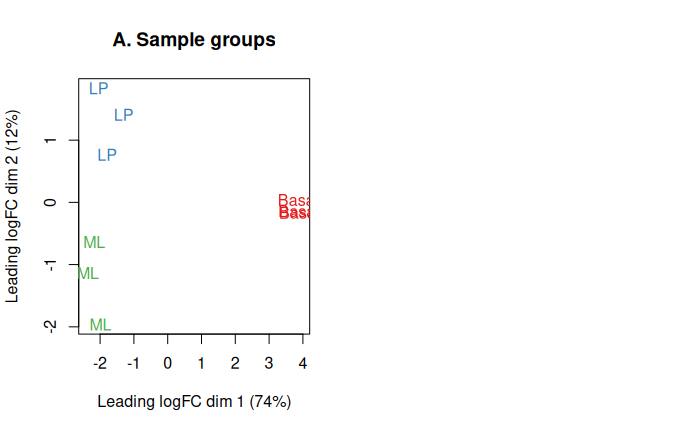

```r
lcpm <- cpm(x, log=TRUE)
par(mfrow=c(1,2))
col.group <- group
levels(col.group) <-  brewer.pal(nlevels(col.group), "Set1")
col.group <- as.character(col.group)
col.lane <- lane
levels(col.lane) <-  brewer.pal(nlevels(col.lane), "Set2")
col.lane <- as.character(col.lane)
plotMDS(lcpm, labels=group, col=col.group)
title(main="A. Sample groups")
```

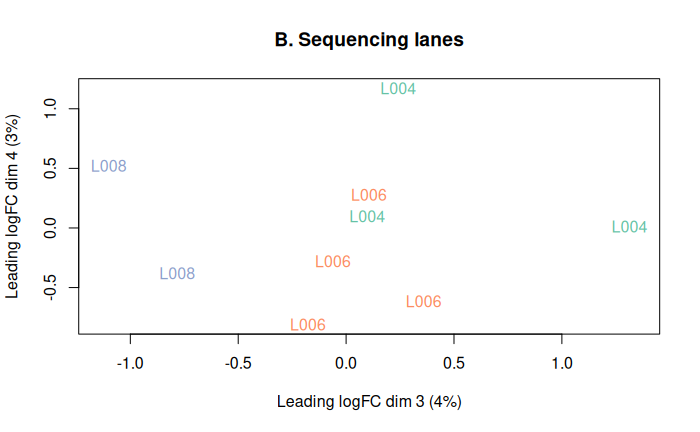

```r
plotMDS(lcpm, labels=lane, col=col.lane, dim=c(3,4))
title(main="B. Sequencing lanes")
```

The following code gives a way nicer, interactive plot. The graph can be accessed via the html file in the glimma-plots folder in your project.

```r
glMDSPlot(lcpm, labels=paste(group, lane, sep="_"), groups=x$samples[,c(2,5)],
         launch=FALSE)
```

The first dimension represent the leading fold change, here ML and LP cluster together and basal is seen as a different group. ML and LP have a -2 logFC and basal 4 logFC. beacuse it is a log2, so 2^6 = 64 times difference in expression. The first dimension also explains ~70%, followed by 2nd: ~10%, and 3rd and 4th less than 5%. So we expect the see the biggest difference between: 1) basal and LP 2) basal and ML the next strongest (although weaker) difference is between ML and LP. the samples cluster by group, so we should see a steady difference between groups, and not much between samples in the group. Does this make sense?

In the second plot, the lanes kinda cluster together, but not much. I think that’s good, so we can neglect the differences between lanes?

# Differential expression analysis

## Creating a design matrix and contrasts

This is basically a binary way to tell the difference between groups and lanes. Easy peasy, but there is a funny thing. A true for groups tells from what sample it comes, so 3 bits for representation, with a 1 telling which group. but for the lanes we do something different! There are 3 lanes, in which: 00 = lane 4 01 = lane 8 10 = lane 6

```r
group
```

```
[1] LP    ML    Basal Basal ML    LP    Basal ML    LP
Levels: Basal LP ML
```

```r
lane
```

```
[1] L004 L004 L004 L006 L006 L006 L006 L008 L008
Levels: L004 L006 L008
```

```r
model.matrix(~0+group+lane) # the ~0 is (probably) used to transform the categories to boolean
```

```
  groupBasal groupLP groupML laneL006 laneL008
1          0       1       0        0        0
2          0       0       1        0        0
3          1       0       0        0        0
4          1       0       0        1        0
5          0       0       1        1        0
6          0       1       0        1        0
7          1       0       0        1        0
8          0       0       1        0        1
9          0       1       0        0        1
attr(,"assign")
[1] 1 1 1 2 2
attr(,"contrasts")
attr(,"contrasts")$group
[1] "contr.treatment"

attr(,"contrasts")$lane
[1] "contr.treatment"
```

we can create better column names by removing the word group.

```r
design <- model.matrix(~0+group+lane)
colnames(design) <- gsub("group", "", colnames(design))
design
```

```
  Basal LP ML laneL006 laneL008
1     0  1  0        0        0
2     0  0  1        0        0
3     1  0  0        0        0
4     1  0  0        1        0
5     0  0  1        1        0
6     0  1  0        1        0
7     1  0  0        1        0
8     0  0  1        0        1
9     0  1  0        0        1
attr(,"assign")
[1] 1 1 1 2 2
attr(,"contrasts")
attr(,"contrasts")$group
[1] "contr.treatment"

attr(,"contrasts")$lane
[1] "contr.treatment"
```

Every line just indicates the attributes of every sample. You’re just telling the model what the difference is between samples. The 1 and 0 act as a mask (multiply by 0 removes values).

It’s funny, i used to not grasp this concept that well. But after coding a lot and and having worked at BaseClear (micro org sequencing company) I don’t find this difficult.

```r
contr.matrix <- makeContrasts(
   BasalvsLP = Basal - LP,
   BasalvsML = Basal - ML,
   LPvsML = LP - ML,
   levels = colnames(design))
contr.matrix
```

```
          Contrasts
Levels     BasalvsLP BasalvsML LPvsML
  Basal            1         1      0
  LP              -1         0      1
  ML               0        -1     -1
  laneL006         0         0      0
  laneL008         0         0      0
```

Here we made the contrast matrix. wait, does this represent (new-old)/old?

If basal has a higher fold change than lp, then basalvslp is positive. if lp has a higher fold change, basalvslp is negative. oooh, so -1 or 1 indicates which group has the higher fold change. I thing i get it, the model gives a differnce between groups, but doesn’t care about if the difference is a net plus or a net min for the involved groups. the contrast matrix pts this info back into the model reuslts. (my guess) I got it: https://bookdown.org/pingapang9/linear_models_bookdown/contrasts.html The model is just a function (y=ax+B) that will explain the data. the contrast matrix makes sure that the slope is displayed correctly for every comparison.

The linear modeling of limma can take experimental complexity into account (multiple samples per group, different lanes) by using the design matrix, like i expected.

## Removing heteroscedascity from count data

“It has been shown that for RNA-seq count data, the variance is not independent of the mean” in other words: if the average goes higher, it does not mean that al data points move according to the change. back to biology: a count is kinda like 1 RNA molecule for a gene that exists. So (after correcting for library size) if 1 gene produces more RNA, not every gene produces more RNA in the same ratio. So i guess there is a finite amount of RNA-polymerase and not every gene in the DNA is producing RNA. That makes some sense, although the cell can just make more RNA-polymerase? whatever, i’m thinking too much.

“In limma, linear modelling is carried out on the log-CPM values which are assumed to be normally distributed and the mean-variance relationship is accommodated using precision weights calculated by the voom function.” So the data is not normaly distributed? Is that because of the previous info? It’s not as if 1 gene produces more RNA, every gene produces more RNA. Some are more active than others. Or even more precise: some pathways are more active than others. So you will see a peak at pathways specific genes, not all genes.

wait: if the data is not normaly distributed, and you need normalised data for the linear model, then why the fuck are we using a nlinear model in the first place??!?!?!? I know it is for simplicity’s sake, but this feels wrong. maybe i’m wrong somewhere.

“Experiments with high biological variation usually result in flatter trends, where variance values plateau at high expression values. Experiments with low biological variation tend to result in sharp decreasing trends.”

“Where sample-level variation is evident from earlier inspections of the MDS plot, the voomWithQualityWeights function can be used to simultaneously incorporate sample-level weights together with the abundance dependent weights estimated by voom”

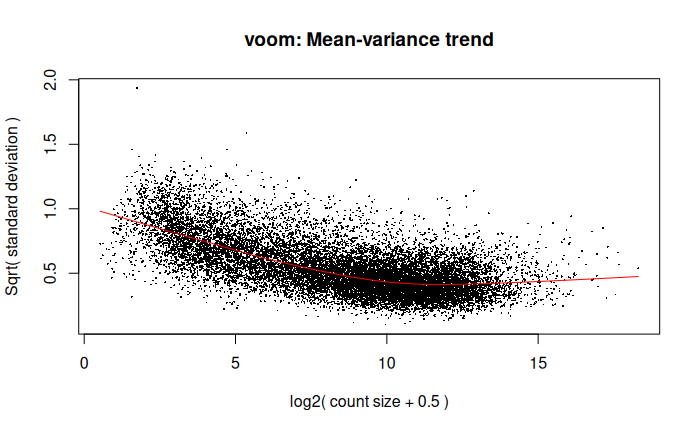

```r
v <- voom(x, design, plot=TRUE)
```

```r
v
```

```
An object of class "EList"
$genes
  ENTREZID SYMBOL TXCHROM
1   497097   Xkr4    chr1
5    20671  Sox17    chr1
6    27395 Mrpl15    chr1
7    18777 Lypla1    chr1
9    21399  Tcea1    chr1
16619 more rows ...

$targets
                             files group lib.size norm.factors lane
10_6_5_11 GSM1545535_10_6_5_11.txt    LP 29387429    0.8943956 L004
9_6_5_11   GSM1545536_9_6_5_11.txt    ML 36212498    1.0250186 L004
purep53     GSM1545538_purep53.txt Basal 59771061    1.0459005 L004
JMS8-2       GSM1545539_JMS8-2.txt Basal 53711278    1.0458455 L006
JMS8-3       GSM1545540_JMS8-3.txt    ML 77015912    1.0162707 L006
JMS8-4       GSM1545541_JMS8-4.txt    LP 55769890    0.9217132 L006
JMS8-5       GSM1545542_JMS8-5.txt Basal 54863512    0.9961959 L006
JMS9-P7c   GSM1545544_JMS9-P7c.txt    ML 23139691    1.0861026 L008
JMS9-P8c   GSM1545545_JMS9-P8c.txt    LP 19634459    0.9839203 L008

$E
        Samples
Tags     10_6_5_11  9_6_5_11   purep53     JMS8-2    JMS8-3    JMS8-4    JMS8-5   JMS9-P7c  JMS9-P8c
  497097 -4.292165 -3.856488 2.5185849  3.2931366 -4.459730 -3.994060 3.2869677 -3.2103696 -5.295316
  20671  -4.292165 -4.593453 0.3560126 -0.4073032 -1.200995 -1.943434 0.8442767 -0.3228444 -1.207853
  27395   3.876089  4.413107 4.5170045  4.5617546  4.344401  3.786363 3.8990635  4.3396075  4.124644
  18777   4.708774  5.571872 5.3964008  5.1623650  5.649355  5.081611 5.0602470  5.7513694  5.142436
  21399   4.785541  4.754537 5.3703795  5.1220551  4.869586  4.943840 5.1384776  5.0308985  4.979644
16619 more rows ...

$weights
          [,1]      [,2]      [,3]      [,4]      [,5]      [,6]      [,7]      [,8]      [,9]
[1,]  1.079413  1.332986 19.826915 20.273253  1.993686  1.395853 20.494977  1.107780  1.079413
[2,]  1.170357  1.456380  4.804866  8.660025  3.612508  2.626870  8.760149  3.211473  2.541942
[3,] 20.219073 25.573792 30.434759 28.528310 31.352260 25.743247 28.722497 21.200072 16.657930
[4,] 26.947557 32.505933 33.583128 33.232125 34.231754 32.354158 33.334340 30.348630 24.259801
[5,] 26.610864 28.501638 33.645479 33.206374 33.573492 31.996623 33.308490 25.171513 23.573305
16619 more rows ...

$design
  Basal LP ML laneL006 laneL008
1     0  1  0        0        0
2     0  0  1        0        0
3     1  0  0        0        0
4     1  0  0        1        0
5     0  0  1        1        0
6     0  1  0        1        0
7     1  0  0        1        0
8     0  0  1        0        1
9     0  1  0        0        1
attr(,"assign")
[1] 1 1 1 2 2
attr(,"contrasts")
attr(,"contrasts")$group
[1] "contr.treatment"

attr(,"contrasts")$lane
[1] "contr.treatment"
```

## Fitting linear models for comparisons of interest

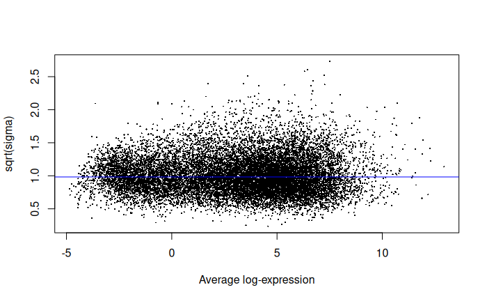

```r
vfit <- lmFit(v, design)
vfit <- contrasts.fit(vfit, contrasts=contr.matrix)
efit <- eBayes(vfit)
plotSA(efit)
```

## Examining the number of DE genes

Le’s check the amount of up and down regulated genes. default p-value cutodd is at 5%. this one uses ebayes.

```r
summary(decideTests(efit))
```

```
       BasalvsLP BasalvsML LPvsML
Down        4648      4927   3135
NotSig      7113      7026  10972
Up          4863      4671   2517
```

“LP and ML (luminal and luminal proginator) are indeed more the same, as expected from me MDS plot.” “The treat method can be used to calculate p-values from empirical Bayes moderated t-statistics with a minimum log-FC requirement.”

LPvsML isn’t that much different from the MDS plot.

```r
tfit <- treat(vfit, lfc=1)
dt <- decideTests(tfit)
summary(dt)
```

```
       BasalvsLP BasalvsML LPvsML
Down        1632      1777    224
NotSig     12976     12790  16210
Up          2016      2057    190
```

This looks more in line with the MDS plot, as in: not much difference between proginator an luminal cells compared to the basal stemcells.

let’s look at the raw data: 1 = upregulated, 0 is no significant difference, -1 is downregulated.

```r
dt
```

```
TestResults matrix
        Contrasts
         BasalvsLP BasalvsML LPvsML
  497097         1         1      0
  20671          0         0      0
  27395          0         0      0
  18777          0         0      0
  21399          0         0      0
16619 more rows ...
```

```r
de.common <- which(dt[,1]!=0 & dt[,2]!=0)
length(de.common)
```

```
[1] 2784
```

The first 20 of the differential expressed genes.

```r
head(tfit$genes$SYMBOL[de.common], n=20)
```

```
 [1] "Xkr4"          "Rgs20"         "Cpa6"          "A830018L16Rik" "Sulf1"         "Eya1"          "Msc"           "Sbspon"
 [9] "Pi15"          "Crispld1"      "Kcnq5"         "Rims1"         "Khdrbs2"       "Ptpn18"        "Prss39"        "Arhgef4"
[17] "Cnga3"         "Cracdl"        "Aff3"          "Npas2"
```

```r
dt[,1:2]
```

```
TestResults matrix
        Contrasts
         BasalvsLP BasalvsML
  497097         1         1
  20671          0         0
  27395          0         0
  18777          0         0
  21399          0         0
16619 more rows ...
```

Venn diagram of up and down regulated genes. no difference is nated as a number outside the venn diagram. results are written to file.

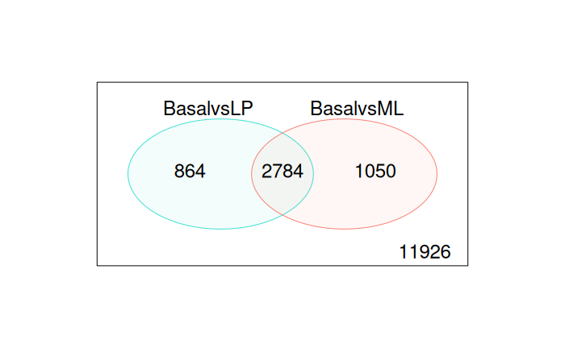

```r
vennDiagram(dt[,1:2], circle.col=c("turquoise", "salmon"))
```

```r
write.fit(tfit, dt, file="results.txt")
```

## Examining individual DE genes from top to bottom

```r
basal.vs.lp <- topTreat(tfit, coef=1, n=Inf, )
basal.vs.ml <- topTreat(tfit, coef=2, n=Inf)
head(basal.vs.lp)
```

|  | ENTREZID | SYMBOL | TXCHROM | logFC | AveExpr | t | P.Value | adj.P.Val |
| --- | --- | --- | --- | --- | --- | --- | --- | --- |
| 12759 | 12759 | Clu | chr14 | -5.455444 | 8.856581 | -33.55508 | 1.723731e-10 | 1.707586e-06 |
| 53624 | 53624 | Cldn7 | chr11 | -5.527356 | 6.295437 | -31.97515 | 2.576972e-10 | 1.707586e-06 |
| 242505 | 242505 | Rasef | chr4 | -5.935249 | 5.118259 | -31.33407 | 3.081544e-10 | 1.707586e-06 |
| 67451 | 67451 | Pkp2 | chr16 | -5.738665 | 4.419170 | -29.85616 | 4.575686e-10 | 1.739242e-06 |
| 228543 | 228543 | Rhov | chr2 | -6.264208 | 5.485314 | -29.07484 | 5.782844e-10 | 1.739242e-06 |
| 70350 | 70350 | Basp1 | chr15 | -6.084738 | 5.247023 | -28.26649 | 7.267694e-10 | 1.739242e-06 |

```r
head(basal.vs.ml)
```

|  | ENTREZID | SYMBOL | TXCHROM | logFC | AveExpr | t | P.Value | adj.P.Val |
| --- | --- | --- | --- | --- | --- | --- | --- | --- |
| 242505 | 242505 | Rasef | chr4 | -6.534668 | 5.118259 | -35.08270 | 1.226399e-10 | 1.236213e-06 |
| 53624 | 53624 | Cldn7 | chr11 | -5.495888 | 6.295437 | -31.68918 | 2.774140e-10 | 1.236213e-06 |
| 12521 | 12521 | Cd82 | chr2 | -4.690834 | 7.069637 | -31.43063 | 2.913572e-10 | 1.236213e-06 |
| 20661 | 20661 | Sort1 | chr3 | -4.931660 | 6.704459 | -30.70113 | 3.558720e-10 | 1.236213e-06 |
| 71740 | 71740 | Nectin4 | chr1 | -5.581283 | 5.164967 | -30.59775 | 3.718157e-10 | 1.236213e-06 |
| 12759 | 12759 | Clu | chr14 | -4.686826 | 8.856581 | -27.95760 | 7.687544e-10 | 1.480434e-06 |

## Useful graphical representations of differential expression results

press ctrl+alt+i for new code cell

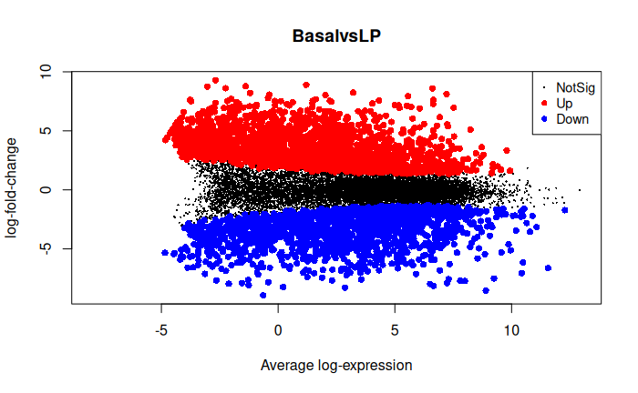

```r
plotMD(tfit, column=1, status=dt[,1], main=colnames(tfit)[1], xlim=c(-8,13))
```

We can make a nicer graphic with glimma:

```r
glMDPlot(tfit, coef=1, status=dt, main=colnames(tfit)[1],
         side.main="ENTREZID", counts=lcpm, groups=group, launch=FALSE)
```

The plot can be found at glimma-plots/MD-Plot.html.

“Heatmaps allow users to look at the expression of a subset of genes.”

The heatmap is for the top 100 DE genes (ranked by adjusted p-value) from basal versus LP.

```r
library(gplots)
basal.vs.lp.topgenes <- basal.vs.lp$ENTREZID[1:100]
i <- which(v$genes$ENTREZID %in% basal.vs.lp.topgenes)
mycol <- colorpanel(1000,"blue","white","red")
```

[output not shown]

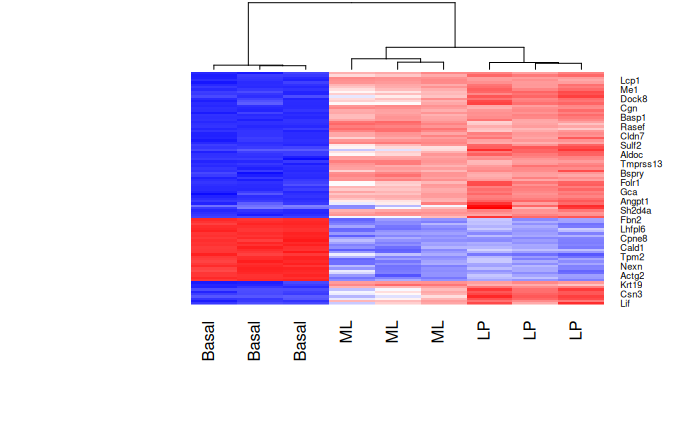

```r
pl <- heatmap.2(lcpm[i,],
                scale="row",
                labRow=v$genes$SYMBOL[i],
                labCol=group,
                col=mycol,
                trace="none",
                density.info="none",
                margin=c(8,6),
                lhei=c(2,10),
                dendrogram="column")
```

It would be better to just create a file so all genes can be shown.

# Gene set testing with camera

```r
load(url("http://bioinf.wehi.edu.au/software/MSigDB/mouse_c2_v5p1.rdata"))
idx <- ids2indices(Mm.c2,id=rownames(v))
cam.BasalvsLP <- camera(v,idx,design,contrast=contr.matrix[,1])
head(cam.BasalvsLP,5)
```

|  | NGenes | Direction | PValue | FDR |
| --- | --- | --- | --- | --- |
| LIM_MAMMARY_STEM_CELL_UP | 791 | Up | 1.768426e-18 | 8.355813e-15 |
| LIM_MAMMARY_STEM_CELL_DN | 683 | Down | 4.027711e-14 | 8.691057e-11 |
| ROSTY_CERVICAL_CANCER_PROLIFERATION_CLUSTER | 170 | Up | 5.518131e-14 | 8.691057e-11 |
| LIM_MAMMARY_LUMINAL_PROGENITOR_UP | 94 | Down | 2.737492e-13 | 3.233663e-10 |
| SOTIRIOU_BREAST_CANCER_GRADE_1_VS_3_UP | 190 | Up | 5.155264e-13 | 4.871724e-10 |

```r
cam.BasalvsML <- camera(v,idx,design,contrast=contr.matrix[,2])
head(cam.BasalvsML,5)
```

|  | NGenes | Direction | PValue | FDR |
| --- | --- | --- | --- | --- |
| LIM_MAMMARY_STEM_CELL_UP | 791 | Up | 1.676651e-22 | 7.922177e-19 |
| LIM_MAMMARY_STEM_CELL_DN | 683 | Down | 7.790412e-18 | 1.840485e-14 |
| LIM_MAMMARY_LUMINAL_MATURE_DN | 172 | Up | 9.744096e-16 | 1.534695e-12 |
| LIM_MAMMARY_LUMINAL_MATURE_UP | 204 | Down | 1.151832e-12 | 1.360602e-09 |
| NAKAYAMA_SOFT_TISSUE_TUMORS_PCA2_UP | 137 | Up | 2.240253e-12 | 1.880160e-09 |

```r
cam.LPvsML <- camera(v,idx,design,contrast=contr.matrix[,3])
head(cam.LPvsML,5)
```

|  | NGenes | Direction | PValue | FDR |
| --- | --- | --- | --- | --- |
| LIM_MAMMARY_LUMINAL_MATURE_DN | 172 | Up | 6.733173e-14 | 2.354935e-10 |
| LIM_MAMMARY_LUMINAL_MATURE_UP | 204 | Down | 9.967980e-14 | 2.354935e-10 |
| LIM_MAMMARY_LUMINAL_PROGENITOR_UP | 94 | Up | 1.317692e-11 | 2.075364e-08 |
| REACTOME_RESPIRATORY_ELECTRON_TRANSPORT | 94 | Down | 7.013195e-09 | 8.284337e-06 |
| REACTOME_RNA_POL_I_PROMOTER_OPENING | 46 | Down | 2.037210e-08 | 1.925163e-05 |

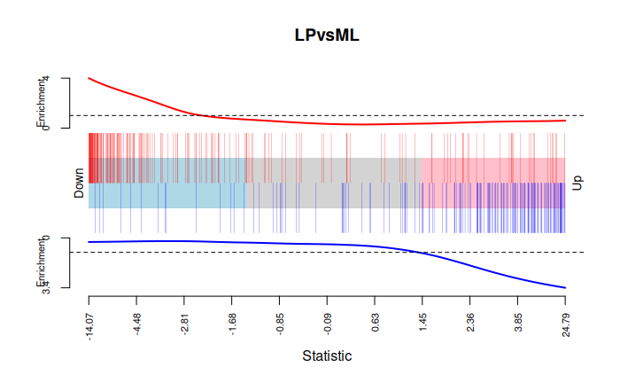

red bars = LIM_MAMMARY_LUMINAL_MATURE_UP blue bars = LIM_MAMMARY_LUMINAL_MATURE_DN

“For each set, an enrichment line that shows the relative enrichment of the vertical bars in each part of the plot is displayed.”

“In other words, camera is more appropriate when “fishing” for gene sets of interest, whereas mroast tests sets that are already of interest for significance.”

The graph is 180* mirrord, (inverse correlation) is the result of the way the contrasts has been set up.

> > > > I’m tired, so brain is not working well. what conclusion cani take from this graph? What do the labels even represent? [“Barcode plots are often used in conjunction with gene set tests, and show the enrichment of gene sets amongst high or low ranked genes.”](https://rdrr.io/bioc/limma/man/barcodeplot.html)

[video explenation](https://www.youtube.com/watch?v=Yi4d7JIlAsM) << watch

this GSEA plot is not like a regular plot. Is it an GSEA plot? The R docs say it an Barcode Enrichment Plot. [I found a nice website which explains a lot of bio statistics](https://biostatsquid.com/pathway-enrichment-analysis-plots/)

https://f1000research.com/articles/5-1408/v3#f1